# chap5.R

hahsler

2020-06-21

This code covers chapter 5 of *“Introduction to Data Mining”* by Pang-Ning Tan, Michael Steinbach and Vipin Kumar. **See [table of contents](https://github.com/mhahsler/Introduction_to_Data_Mining_R_Examples#readme) for code examples for other chapters.**

This work is licensed under the [Creative Commons Attribution 4.0 International License](http://creativecommons.org/licenses/by/4.0/). For questions please contact [Michael Hahsler](http://michael.hahsler.net).

# Used packages

Install the following packages.

- [`arules`](https://www.rdocumentation.org/packages/arules/)
- [`arulesViz`](https://www.rdocumentation.org/packages/arulesViz/)

```r
library(tidyverse)
```

```r
library(ggplot2)

library(arules)
library(arulesViz)
```

For information about the `arules` package try: `help(package="arules")` and `vignette("arules")` (also available at [CRAN](http://cran.r-project.org/web/packages/arules/vignettes/arules.pdf))

## S4 object system

Standard R objects use the [S3 object system](http://adv-r.had.co.nz/S3.html) which do not use formal class definitions and are usually implemented as a list with a class attribute. `arules` and many other R packages use the [S4 object system](http://adv-r.had.co.nz/S4.html) which is based on formal class definitions (similar to object-oriented programming languages like Java and C++). Some important differences of using S4 objects compared to the usual S3 objects are:

- coercion (casting): `as(from, "class_name")`
- help: `class? class_name`

# Used data

```r
data(Zoo, package = "mlbench")
head(Zoo)
```

```
##           hair feathers  eggs  milk airborne aquatic predator toothed backbone
## aardvark  TRUE    FALSE FALSE  TRUE    FALSE   FALSE     TRUE    TRUE     TRUE
## antelope  TRUE    FALSE FALSE  TRUE    FALSE   FALSE    FALSE    TRUE     TRUE
## bass     FALSE    FALSE  TRUE FALSE    FALSE    TRUE     TRUE    TRUE     TRUE
## bear      TRUE    FALSE FALSE  TRUE    FALSE   FALSE     TRUE    TRUE     TRUE
## boar      TRUE    FALSE FALSE  TRUE    FALSE   FALSE     TRUE    TRUE     TRUE
## buffalo   TRUE    FALSE FALSE  TRUE    FALSE   FALSE    FALSE    TRUE     TRUE
##          breathes venomous  fins legs  tail domestic catsize   type
## aardvark     TRUE    FALSE FALSE    4 FALSE    FALSE    TRUE mammal
## antelope     TRUE    FALSE FALSE    4  TRUE    FALSE    TRUE mammal
## bass        FALSE    FALSE  TRUE    0  TRUE    FALSE   FALSE   fish
## bear         TRUE    FALSE FALSE    4 FALSE    FALSE    TRUE mammal
## boar         TRUE    FALSE FALSE    4  TRUE    FALSE    TRUE mammal
## buffalo      TRUE    FALSE FALSE    4  TRUE    FALSE    TRUE mammal
```

# Transactions

## Create transactions

The data in the data.frame need to be converted into a set of transactions where each row represents a transaction and each column is translated into items. For the Zoo data set this means that we consider animals as transactions and the different traits (features) will become items that each animal has. For example the animal *antelope* has the item *hair* in its transaction.

```r
trans <- as(Zoo, "transactions")
```

```
## Warning: Column(s) 13 not logical or factor. Applying default discretization
## (see '? discretizeDF').
```

The conversion gives a warning because only discrete features (`factor` and `logical`) can be directly translated into items. Continuous features need to be discretizes first.

What is column 13?

```r
summary(Zoo[13])
```

```
##       legs
##  Min.   :0.000
##  1st Qu.:2.000
##  Median :4.000
##  Mean   :2.842
##  3rd Qu.:4.000
##  Max.   :8.000
```

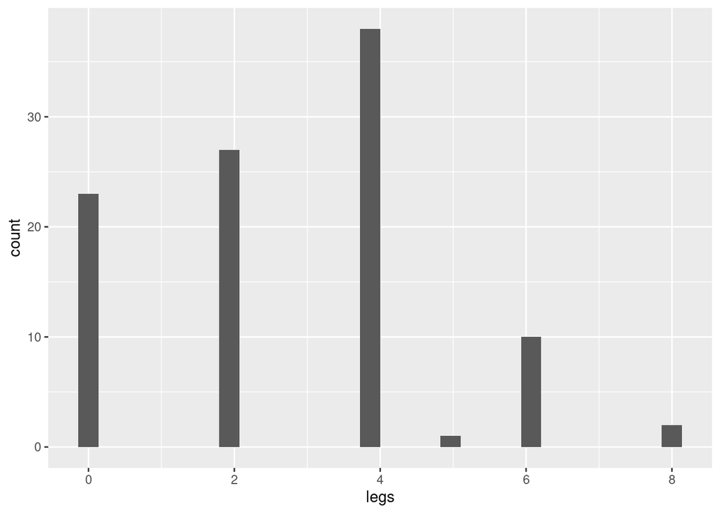

```r
ggplot(Zoo, aes(legs)) + geom_histogram()
```

```r
table(Zoo$legs)
```

```
##
##  0  2  4  5  6  8
## 23 27 38  1 10  2
```

Possible solution: Make legs into has/does not have legs

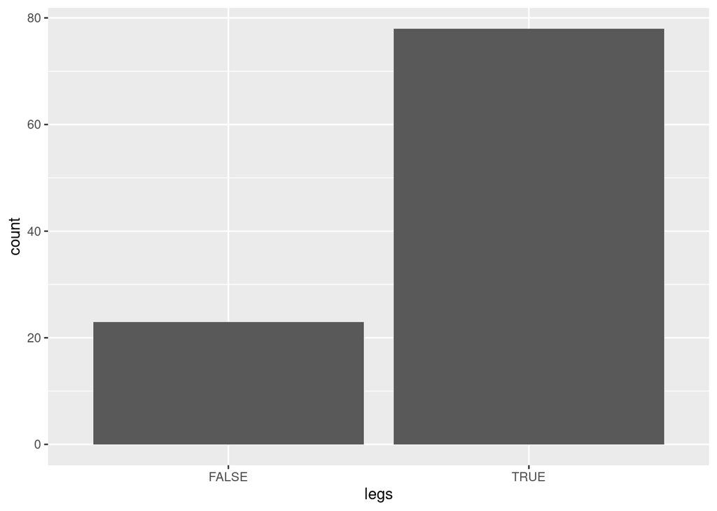

```r
Zoo_has_legs <- Zoo %>% mutate(legs = legs > 0)
ggplot(Zoo_has_legs, aes(legs)) + geom_bar()
```

```r
table(Zoo_has_legs$legs)
```

```
##
## FALSE  TRUE
##    23    78
```

**Alternatives:**

- use each unique value as an item:

```r
Zoo_unique_leg_values <- Zoo %>% mutate(legs = factor(legs))
head(Zoo_unique_leg_values$legs)
```

```
## [1] 4 4 0 4 4 4
## Levels: 0 2 4 5 6 8
```

- discretize (see [`? discretize`](https://www.rdocumentation.org/packages/arules/topics/discretize) and discretization in the code for Chapter 2):

```r
Zoo_discretized_legs <- Zoo %>% mutate(
  legs = discretize(legs, breaks = 2, method="interval")
)
table(Zoo_discretized_legs$legs)
```

```
##
## [0,4) [4,8]
##    50    51
```

Convert data into a set of transactions

```r
trans <- as(Zoo_has_legs, "transactions")
trans
```

```
## transactions in sparse format with
##  101 transactions (rows) and
##  23 items (columns)
```

## Inspect Transactions

```r
summary(trans)
```

```
## transactions as itemMatrix in sparse format with
##  101 rows (elements/itemsets/transactions) and
##  23 columns (items) and a density of 0.3611709
##
## most frequent items:
## backbone breathes     legs     tail  toothed  (Other)
##       83       80       78       75       61      462
##
## element (itemset/transaction) length distribution:
## sizes
##  3  4  5  6  7  8  9 10 11 12
##  3  2  6  5  8 21 27 25  3  1
##
##    Min. 1st Qu.  Median    Mean 3rd Qu.    Max.
##   3.000   8.000   9.000   8.307  10.000  12.000
##
## includes extended item information - examples:
##     labels variables levels
## 1     hair      hair   TRUE
## 2 feathers  feathers   TRUE
## 3     eggs      eggs   TRUE
##
## includes extended transaction information - examples:
##   transactionID
## 1             1
## 2             2
## 3             3
```

Look at created items. They are still called column names since the transactions are actually stored as a large sparse logical matrix (see below).

```r
colnames(trans)
```

```
##  [1] "hair"               "feathers"           "eggs"
##  [4] "milk"               "airborne"           "aquatic"
##  [7] "predator"           "toothed"            "backbone"
## [10] "breathes"           "venomous"           "fins"
## [13] "legs"               "tail"               "domestic"
## [16] "catsize"            "type=mammal"        "type=bird"
## [19] "type=reptile"       "type=fish"          "type=amphibian"
## [22] "type=insect"        "type=mollusc.et.al"
```

Compare with the original features (column names) from Zoo

```r
colnames(Zoo)
```

```
##  [1] "hair"     "feathers" "eggs"     "milk"     "airborne" "aquatic"
##  [7] "predator" "toothed"  "backbone" "breathes" "venomous" "fins"
## [13] "legs"     "tail"     "domestic" "catsize"  "type"
```

Look at a (first) few transactions as a matrix. 1 indicates the presence of an item.

```r
as(trans, "matrix")[1:3,]
```

```
##    hair feathers  eggs  milk airborne aquatic predator toothed backbone
## 1  TRUE    FALSE FALSE  TRUE    FALSE   FALSE     TRUE    TRUE     TRUE
## 2  TRUE    FALSE FALSE  TRUE    FALSE   FALSE    FALSE    TRUE     TRUE
## 3 FALSE    FALSE  TRUE FALSE    FALSE    TRUE     TRUE    TRUE     TRUE
##   breathes venomous  fins  legs  tail domestic catsize type=mammal type=bird
## 1     TRUE    FALSE FALSE  TRUE FALSE    FALSE    TRUE        TRUE     FALSE
## 2     TRUE    FALSE FALSE  TRUE  TRUE    FALSE    TRUE        TRUE     FALSE
## 3    FALSE    FALSE  TRUE FALSE  TRUE    FALSE   FALSE       FALSE     FALSE
##   type=reptile type=fish type=amphibian type=insect type=mollusc.et.al
## 1        FALSE     FALSE          FALSE       FALSE              FALSE
## 2        FALSE     FALSE          FALSE       FALSE              FALSE
## 3        FALSE      TRUE          FALSE       FALSE              FALSE
```

Look at the transactions as sets of items

```r
inspect(trans[1:3])
```

```
##     items         transactionID
## [1] {hair,
##      milk,
##      predator,
##      toothed,
##      backbone,
##      breathes,
##      legs,
##      catsize,
##      type=mammal}             1
## [2] {hair,
##      milk,
##      toothed,
##      backbone,
##      breathes,
##      legs,
##      tail,
##      catsize,
##      type=mammal}             2
## [3] {eggs,
##      aquatic,
##      predator,
##      toothed,
##      backbone,
##      fins,
##      tail,
##      type=fish}               3
```

Plot the binary matrix. Dark dots represent 1s.

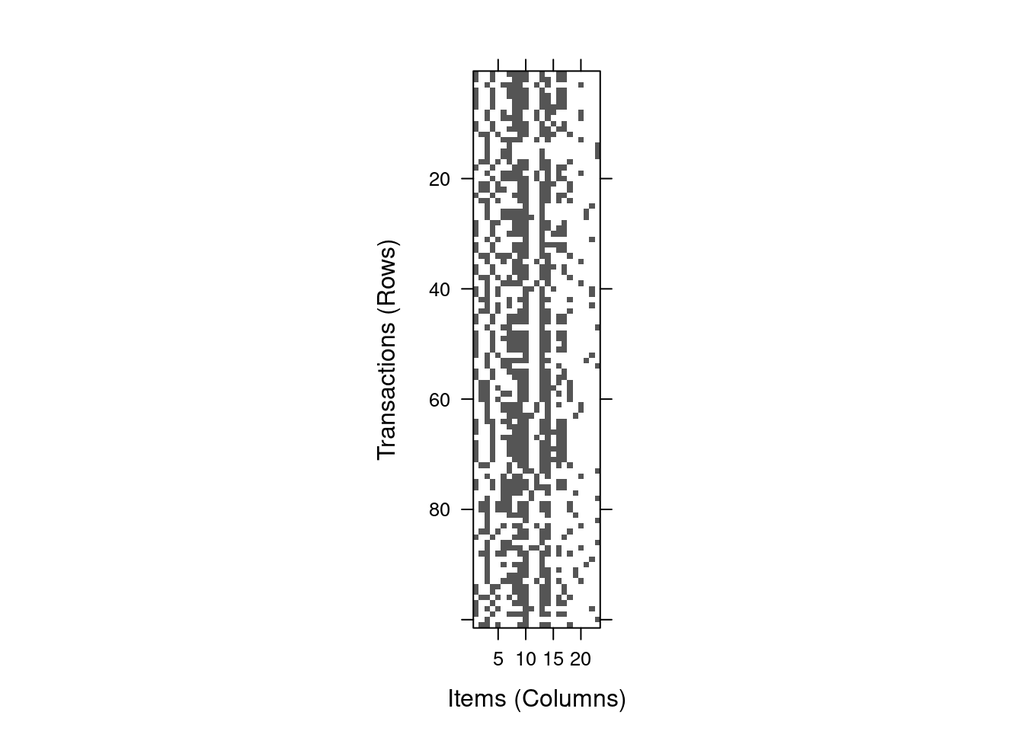

```r
image(trans)
```

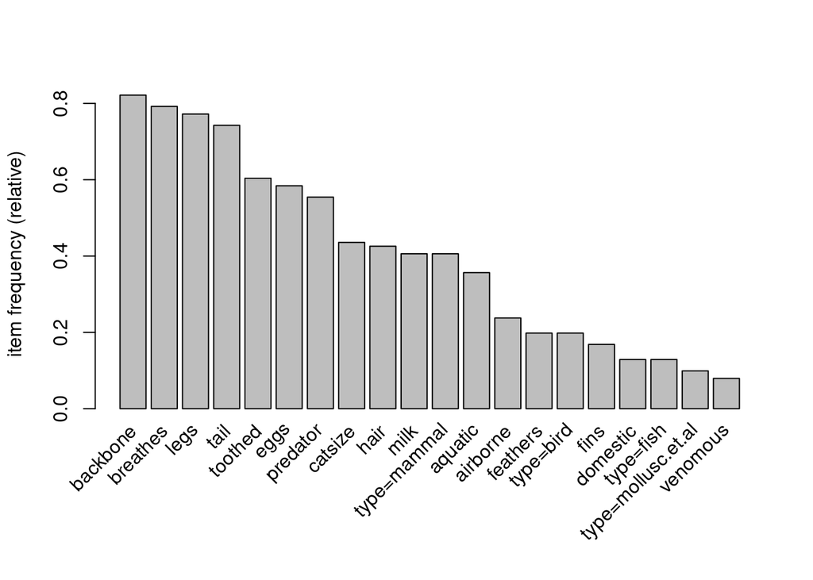

```r
itemFrequencyPlot(trans,topN = 20)
```

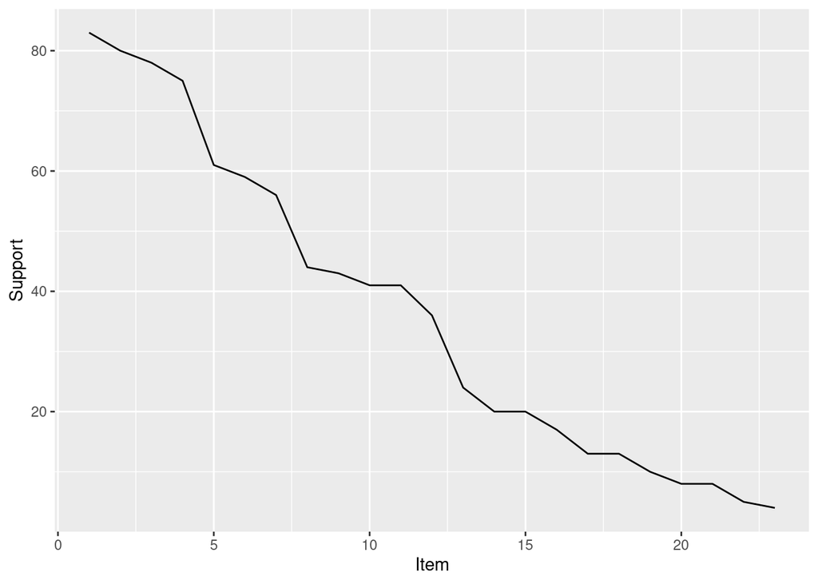

```r
ggplot(
  tibble(
    Support = sort(itemFrequency(trans, type = "absolute"), decreasing = TRUE),
    Item = seq_len(ncol(trans))
  ), aes(x = Item, y = Support)) + geom_line()
```

**Alternative encoding:** Also create items for FALSE (use factor)

```r
sapply(Zoo_has_legs, class)
```

```
##      hair  feathers      eggs      milk  airborne   aquatic  predator   toothed
## "logical" "logical" "logical" "logical" "logical" "logical" "logical" "logical"
##  backbone  breathes  venomous      fins      legs      tail  domestic   catsize
## "logical" "logical" "logical" "logical" "logical" "logical" "logical" "logical"
##      type
##  "factor"
```

```r
Zoo_factors <- Zoo_has_legs %>% mutate_if(is.logical, factor)
sapply(Zoo_factors, class)
```

```
##     hair feathers     eggs     milk airborne  aquatic predator  toothed
## "factor" "factor" "factor" "factor" "factor" "factor" "factor" "factor"
## backbone breathes venomous     fins     legs     tail domestic  catsize
## "factor" "factor" "factor" "factor" "factor" "factor" "factor" "factor"
##     type
## "factor"
```

```r
summary(Zoo_factors)
```

```
##     hair     feathers     eggs       milk     airborne   aquatic    predator
##  FALSE:58   FALSE:81   FALSE:42   FALSE:60   FALSE:77   FALSE:65   FALSE:45
##  TRUE :43   TRUE :20   TRUE :59   TRUE :41   TRUE :24   TRUE :36   TRUE :56
##
##
##
##
##
##   toothed    backbone   breathes   venomous     fins       legs       tail
##  FALSE:40   FALSE:18   FALSE:21   FALSE:93   FALSE:84   FALSE:23   FALSE:26
##  TRUE :61   TRUE :83   TRUE :80   TRUE : 8   TRUE :17   TRUE :78   TRUE :75
##
##
##
##
##
##   domestic   catsize              type
##  FALSE:88   FALSE:57   mammal       :41
##  TRUE :13   TRUE :44   bird         :20
##                        reptile      : 5
##                        fish         :13
##                        amphibian    : 4
##                        insect       : 8
##                        mollusc.et.al:10
```

```r
trans_factors <- as(Zoo_factors, "transactions")
trans_factors
```

```
## transactions in sparse format with
##  101 transactions (rows) and
##  39 items (columns)
```

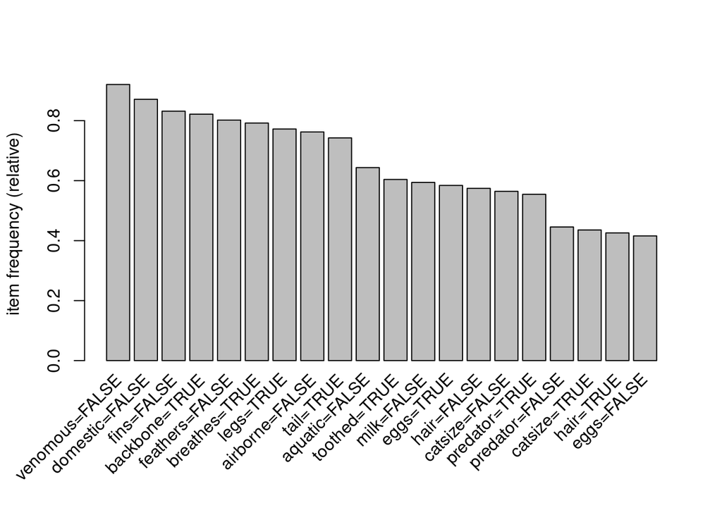

```r
itemFrequencyPlot(trans_factors, topN = 20)
```

```r
# Select transactions that contain a certain item
trans_insects <- trans_factors[trans %in% "type=insect"]
trans_insects
```

```
## transactions in sparse format with
##  8 transactions (rows) and
##  39 items (columns)
```

```r
inspect(trans_insects)
```

```
##     items            transactionID
## [1] {hair=FALSE,
##      feathers=FALSE,
##      eggs=TRUE,
##      milk=FALSE,
##      airborne=FALSE,
##      aquatic=FALSE,
##      predator=FALSE,
##      toothed=FALSE,
##      backbone=FALSE,
##      breathes=TRUE,
##      venomous=FALSE,
##      fins=FALSE,
##      legs=TRUE,
##      tail=FALSE,
##      domestic=FALSE,
##      catsize=FALSE,
##      type=insect}               25
## [2] {hair=FALSE,
##      feathers=FALSE,
##      eggs=TRUE,
##      milk=FALSE,
##      airborne=TRUE,
##      aquatic=FALSE,
##      predator=FALSE,
##      toothed=FALSE,
##      backbone=FALSE,
##      breathes=TRUE,
##      venomous=FALSE,
##      fins=FALSE,
##      legs=TRUE,
##      tail=FALSE,
##      domestic=FALSE,
##      catsize=FALSE,
##      type=insect}               31
## [3] {hair=TRUE,
##      feathers=FALSE,
##      eggs=TRUE,
##      milk=FALSE,
##      airborne=TRUE,
```

[output cut: 82 more lines]

```
##      eggs=TRUE,
##      milk=FALSE,
##      airborne=TRUE,
##      aquatic=FALSE,
##      predator=FALSE,
##      toothed=FALSE,
##      backbone=FALSE,
##      breathes=TRUE,
##      venomous=TRUE,
##      fins=FALSE,
##      legs=TRUE,
##      tail=FALSE,
##      domestic=FALSE,
##      catsize=FALSE,
##      type=insect}               98
```

## Vertical layout (Transaction ID Lists)

The default layout for transactions is horizontal layout (i.e. each transaction is a row). The vertical layout represents transaction data as a list of transaction IDs for each item (= transaction ID lists).

```r
vertical <- as(trans, "tidLists")
as(vertical, "matrix")[1:10, 1:5]
```

```
##              1     2     3     4     5
## hair      TRUE  TRUE FALSE  TRUE  TRUE
## feathers FALSE FALSE FALSE FALSE FALSE
## eggs     FALSE FALSE  TRUE FALSE FALSE
## milk      TRUE  TRUE FALSE  TRUE  TRUE
## airborne FALSE FALSE FALSE FALSE FALSE
## aquatic  FALSE FALSE  TRUE FALSE FALSE
## predator  TRUE FALSE  TRUE  TRUE  TRUE
## toothed   TRUE  TRUE  TRUE  TRUE  TRUE
## backbone  TRUE  TRUE  TRUE  TRUE  TRUE
## breathes  TRUE  TRUE FALSE  TRUE  TRUE
```

# Frequent Itemsets

## Mine Frequent Itemsets

For this dataset we have already a huge number of possible itemsets

```r
2^ncol(trans)
```

```
## [1] 8388608
```

Find frequent itemsets (target=“frequent”) with the default settings.

```r
its <- apriori(trans, parameter=list(target = "frequent"))
```

```
## Apriori
##
## Parameter specification:
##  confidence minval smax arem  aval originalSupport maxtime support minlen
##          NA    0.1    1 none FALSE            TRUE       5     0.1      1
##  maxlen            target  ext
##      10 frequent itemsets TRUE
##
## Algorithmic control:
##  filter tree heap memopt load sort verbose
##     0.1 TRUE TRUE  FALSE TRUE    2    TRUE
##
## Absolute minimum support count: 10
##
## set item appearances ...[0 item(s)] done [0.00s].
## set transactions ...[23 item(s), 101 transaction(s)] done [0.00s].
## sorting and recoding items ... [18 item(s)] done [0.00s].
## creating transaction tree ... done [0.00s].
## checking subsets of size 1 2 3 4 5 6 7 8 9 10
```

```
##  done [0.00s].
## sorting transactions ... done [0.00s].
## writing ... [1465 set(s)] done [0.00s].
## creating S4 object  ... done [0.00s].
```

```r
its
```

```
## set of 1465 itemsets
```

Default minimum support is .1 (10%). **Note:** We use here a very small data set. For larger datasets the default minimum support might be to low and you may run out of memory. You probably want to start out with a higher minimum support like .5 (50%) and then work your way down.

```r
5/nrow(trans)
```

```
## [1] 0.04950495
```

In order to find itemsets that effect 5 animals I need to go down to a support of about 5%.

```r
its <- apriori(trans, parameter=list(target = "frequent", support = 0.05))
```

```
## Apriori
##
## Parameter specification:
##  confidence minval smax arem  aval originalSupport maxtime support minlen
##          NA    0.1    1 none FALSE            TRUE       5    0.05      1
##  maxlen            target  ext
##      10 frequent itemsets TRUE
##
## Algorithmic control:
##  filter tree heap memopt load sort verbose
##     0.1 TRUE TRUE  FALSE TRUE    2    TRUE
##
## Absolute minimum support count: 5
##
## set item appearances ...[0 item(s)] done [0.00s].
## set transactions ...[23 item(s), 101 transaction(s)] done [0.00s].
## sorting and recoding items ... [21 item(s)] done [0.00s].
## creating transaction tree ... done [0.00s].
## checking subsets of size 1 2 3 4 5 6 7 8 9 10
```

```
##  done [0.00s].
## sorting transactions ... done [0.00s].
## writing ... [2537 set(s)] done [0.00s].
## creating S4 object  ... done [0.00s].
```

```r
its
```

```
## set of 2537 itemsets
```

Sort by support

```r
its <- sort(its, by = "support")
inspect(head(its, n = 10))
```

```
##      items                    support   transIdenticalToItemsets count
## [1]  {backbone}               0.8217822 0                        83
## [2]  {breathes}               0.7920792 0                        80
## [3]  {legs}                   0.7722772 0                        78
## [4]  {tail}                   0.7425743 0                        75
## [5]  {backbone,tail}          0.7326733 0                        74
## [6]  {breathes,legs}          0.7227723 0                        73
## [7]  {backbone,breathes}      0.6831683 0                        69
## [8]  {backbone,legs}          0.6336634 0                        64
## [9]  {backbone,breathes,legs} 0.6336634 0                        64
## [10] {toothed}                0.6039604 0                        61
```

Look at frequent itemsets with many items (set breaks manually since Automatically chosen breaks look bad)

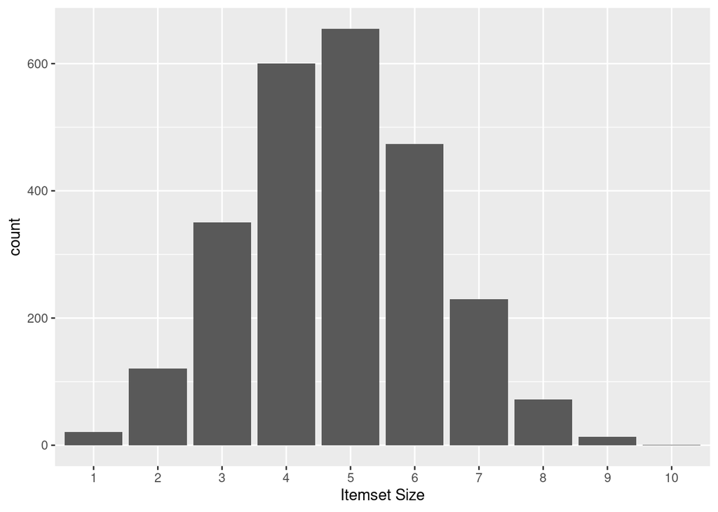

```r
ggplot(tibble(`Itemset Size` = factor(size(its))), aes(`Itemset Size`)) + geom_bar()
```

```r
inspect(its[size(its) > 8])
```

```
##      items            support transIdenticalToItemsets count
## [1]  {hair,
##       milk,
##       toothed,
##       backbone,
##       breathes,
##       legs,
##       tail,
##       catsize,
##       type=mammal} 0.23762376               0.06930693    24
## [2]  {hair,
##       milk,
##       predator,
##       toothed,
##       backbone,
##       breathes,
##       legs,
##       catsize,
##       type=mammal} 0.15841584               0.01980198    16
## [3]  {hair,
##       milk,
##       predator,
##       toothed,
##       backbone,
##       breathes,
##       legs,
##       tail,
##       type=mammal} 0.14851485               0.01980198    15
## [4]  {hair,
##       milk,
##       predator,
##       backbone,
##       breathes,
##       legs,
##       tail,
##       catsize,
##       type=mammal} 0.13861386               0.00000000    14
## [5]  {hair,
##       milk,
##       predator,
```

[output cut: 73 more lines]

```
##       backbone,
##       breathes,
##       legs,
##       tail,
##       domestic,
##       type=mammal} 0.05940594               0.00990099     6
## [14] {feathers,
##       eggs,
##       airborne,
##       predator,
##       backbone,
##       breathes,
##       legs,
##       tail,
##       type=bird}   0.05940594               0.01980198     6
```

## Concise Representation of Itemsets

Find maximal frequent itemsets (no superset if frequent)

```r
its_max <- its[is.maximal(its)]
its_max
```

```
## set of 22 itemsets
```

```r
inspect(head(its_max, by = "support"))
```

```
##     items            support transIdenticalToItemsets count
## [1] {hair,
##      milk,
##      predator,
##      toothed,
##      backbone,
##      breathes,
##      legs,
##      tail,
##      catsize,
##      type=mammal} 0.12871287               0.09900990    13
## [2] {eggs,
##      aquatic,
##      predator,
##      toothed,
##      backbone,
##      fins,
##      tail,
##      type=fish}   0.08910891               0.04950495     9
## [3] {aquatic,
##      predator,
##      toothed,
##      backbone,
##      breathes}    0.07920792               0.00000000     8
## [4] {aquatic,
##      predator,
##      toothed,
##      backbone,
##      fins,
##      tail,
##      catsize}     0.06930693               0.00000000     7
## [5] {eggs,
##      venomous}    0.05940594               0.00000000     6
## [6] {predator,
##      venomous}    0.05940594               0.00000000     6
```

Find closed frequent itemsets (no superset if frequent)

```r
its_closed <- its[is.closed(its)]
its_closed
```

```
## set of 230 itemsets
```

```r
inspect(head(its_closed, by = "support"))
```

```
##     items           support   transIdenticalToItemsets count
## [1] {backbone}      0.8217822 0                        83
## [2] {breathes}      0.7920792 0                        80
## [3] {legs}          0.7722772 0                        78
## [4] {tail}          0.7425743 0                        75
## [5] {backbone,tail} 0.7326733 0                        74
## [6] {breathes,legs} 0.7227723 0                        73
```

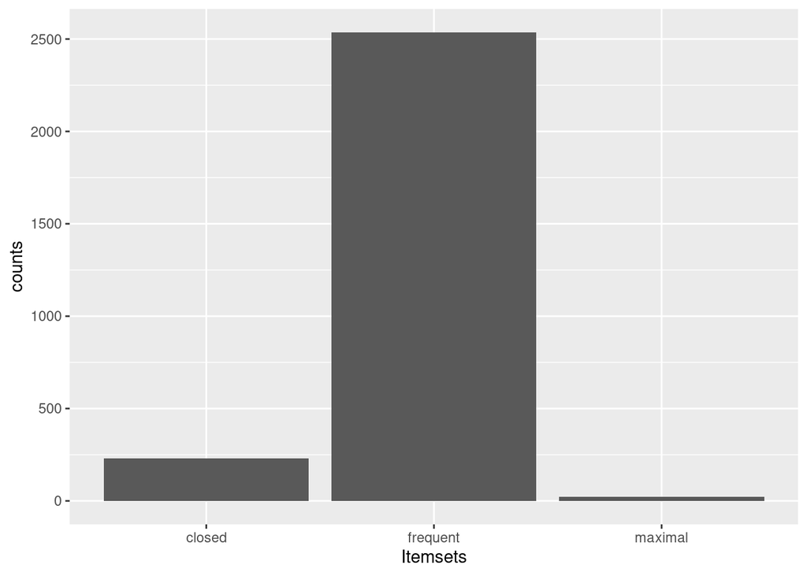

```r
counts <- c(
  frequent=length(its),
  closed=length(its_closed),
  maximal=length(its_max)
)

ggplot(as_tibble(counts, rownames = "Itemsets"),
  aes(Itemsets, counts)) + geom_bar(stat = "identity")
```

# Association Rules

## Mine Association Rules

We use the APRIORI algorithm (see [`? apriori`](https://www.rdocumentation.org/packages/arules/topics/apriori))

```r
rules <- apriori(trans, parameter = list(support = 0.05, confidence = 0.9))
```

```
## Apriori
##
## Parameter specification:
##  confidence minval smax arem  aval originalSupport maxtime support minlen
##         0.9    0.1    1 none FALSE            TRUE       5    0.05      1
##  maxlen target  ext
##      10  rules TRUE
##
## Algorithmic control:
##  filter tree heap memopt load sort verbose
##     0.1 TRUE TRUE  FALSE TRUE    2    TRUE
##
## Absolute minimum support count: 5
##
## set item appearances ...[0 item(s)] done [0.00s].
## set transactions ...[23 item(s), 101 transaction(s)] done [0.00s].
## sorting and recoding items ... [21 item(s)] done [0.00s].
## creating transaction tree ... done [0.00s].
## checking subsets of size 1 2 3 4 5 6 7 8 9 10
```

```
##  done [0.00s].
## writing ... [7174 rule(s)] done [0.00s].
## creating S4 object  ... done [0.00s].
```

```r
length(rules)
```

```
## [1] 7174
```

```r
inspect(head(rules))
```

```
##     lhs                     rhs        support    confidence coverage
## [1] {type=insect}        => {eggs}     0.07920792 1.0        0.07920792
## [2] {type=insect}        => {legs}     0.07920792 1.0        0.07920792
## [3] {type=insect}        => {breathes} 0.07920792 1.0        0.07920792
## [4] {type=mollusc.et.al} => {eggs}     0.08910891 0.9        0.09900990
## [5] {type=fish}          => {fins}     0.12871287 1.0        0.12871287
## [6] {type=fish}          => {aquatic}  0.12871287 1.0        0.12871287
##     lift     count
## [1] 1.711864  8
## [2] 1.294872  8
## [3] 1.262500  8
## [4] 1.540678  9
## [5] 5.941176 13
## [6] 2.805556 13
```

```r
quality(head(rules))
```

```
##      support confidence   coverage     lift count
## 1 0.07920792        1.0 0.07920792 1.711864     8
## 2 0.07920792        1.0 0.07920792 1.294872     8
## 3 0.07920792        1.0 0.07920792 1.262500     8
## 4 0.08910891        0.9 0.09900990 1.540678     9
## 5 0.12871287        1.0 0.12871287 5.941176    13
## 6 0.12871287        1.0 0.12871287 2.805556    13
```

Look at rules with highest lift

```r
rules <- sort(rules, by = "lift")
inspect(head(rules, n = 10))
```

```
##      lhs                             rhs         support    confidence
## [1]  {eggs,fins}                  => {type=fish} 0.12871287 1
## [2]  {eggs,aquatic,fins}          => {type=fish} 0.12871287 1
## [3]  {eggs,predator,fins}         => {type=fish} 0.08910891 1
## [4]  {eggs,toothed,fins}          => {type=fish} 0.12871287 1
## [5]  {eggs,fins,tail}             => {type=fish} 0.12871287 1
## [6]  {eggs,backbone,fins}         => {type=fish} 0.12871287 1
## [7]  {eggs,aquatic,predator,fins} => {type=fish} 0.08910891 1
## [8]  {eggs,aquatic,toothed,fins}  => {type=fish} 0.12871287 1
## [9]  {eggs,aquatic,fins,tail}     => {type=fish} 0.12871287 1
## [10] {eggs,aquatic,backbone,fins} => {type=fish} 0.12871287 1
##      coverage   lift     count
## [1]  0.12871287 7.769231 13
## [2]  0.12871287 7.769231 13
## [3]  0.08910891 7.769231  9
## [4]  0.12871287 7.769231 13
## [5]  0.12871287 7.769231 13
## [6]  0.12871287 7.769231 13
## [7]  0.08910891 7.769231  9
## [8]  0.12871287 7.769231 13
## [9]  0.12871287 7.769231 13
## [10] 0.12871287 7.769231 13
```

Create rules using the alternative encoding (with “FALSE” item)

```r
r <- apriori(trans_factors)
```

```
## Apriori
##
## Parameter specification:
##  confidence minval smax arem  aval originalSupport maxtime support minlen
##         0.8    0.1    1 none FALSE            TRUE       5     0.1      1
##  maxlen target  ext
##      10  rules TRUE
##
## Algorithmic control:
##  filter tree heap memopt load sort verbose
##     0.1 TRUE TRUE  FALSE TRUE    2    TRUE
##
## Absolute minimum support count: 10
##
## set item appearances ...[0 item(s)] done [0.00s].
## set transactions ...[39 item(s), 101 transaction(s)] done [0.00s].
## sorting and recoding items ... [34 item(s)] done [0.00s].
## creating transaction tree ... done [0.00s].
## checking subsets of size 1 2 3 4 5 6 7 8 9 10
```

```
##  done [0.10s].
## writing ... [1517191 rule(s)] done [0.25s].
## creating S4 object  ... done [0.80s].
```

```r
r
```

```
## set of 1517191 rules
```

```r
print(object.size(r), unit = "Mb")
```

```
## 110.2 Mb
```

```r
inspect(r[1:10])
```

```
##      lhs                rhs              support   confidence coverage
## [1]  {}              => {feathers=FALSE} 0.8019802 0.8019802  1.0000000
## [2]  {}              => {backbone=TRUE}  0.8217822 0.8217822  1.0000000
## [3]  {}              => {fins=FALSE}     0.8316832 0.8316832  1.0000000
## [4]  {}              => {domestic=FALSE} 0.8712871 0.8712871  1.0000000
## [5]  {}              => {venomous=FALSE} 0.9207921 0.9207921  1.0000000
## [6]  {domestic=TRUE} => {predator=FALSE} 0.1089109 0.8461538  0.1287129
## [7]  {domestic=TRUE} => {aquatic=FALSE}  0.1188119 0.9230769  0.1287129
## [8]  {domestic=TRUE} => {legs=TRUE}      0.1188119 0.9230769  0.1287129
## [9]  {domestic=TRUE} => {breathes=TRUE}  0.1188119 0.9230769  0.1287129
## [10] {domestic=TRUE} => {backbone=TRUE}  0.1188119 0.9230769  0.1287129
##      lift     count
## [1]  1.000000 81
## [2]  1.000000 83
## [3]  1.000000 84
## [4]  1.000000 88
## [5]  1.000000 93
## [6]  1.899145 11
## [7]  1.434320 12
## [8]  1.195266 12
## [9]  1.165385 12
## [10] 1.123262 12
```

```r
inspect(head(r, n = 10, by = "lift"))
```

```
##      lhs                                        rhs         support
## [1]  {breathes=FALSE,fins=TRUE}              => {type=fish} 0.1287129
## [2]  {eggs=TRUE,fins=TRUE}                   => {type=fish} 0.1287129
## [3]  {milk=FALSE,fins=TRUE}                  => {type=fish} 0.1287129
## [4]  {breathes=FALSE,fins=TRUE,legs=FALSE}   => {type=fish} 0.1287129
## [5]  {aquatic=TRUE,breathes=FALSE,fins=TRUE} => {type=fish} 0.1287129
## [6]  {hair=FALSE,breathes=FALSE,fins=TRUE}   => {type=fish} 0.1287129
## [7]  {eggs=TRUE,breathes=FALSE,fins=TRUE}    => {type=fish} 0.1287129
## [8]  {milk=FALSE,breathes=FALSE,fins=TRUE}   => {type=fish} 0.1287129
## [9]  {toothed=TRUE,breathes=FALSE,fins=TRUE} => {type=fish} 0.1287129
## [10] {breathes=FALSE,fins=TRUE,tail=TRUE}    => {type=fish} 0.1287129
##      confidence coverage  lift     count
## [1]  1          0.1287129 7.769231 13
## [2]  1          0.1287129 7.769231 13
## [3]  1          0.1287129 7.769231 13
## [4]  1          0.1287129 7.769231 13
## [5]  1          0.1287129 7.769231 13
## [6]  1          0.1287129 7.769231 13
## [7]  1          0.1287129 7.769231 13
## [8]  1          0.1287129 7.769231 13
## [9]  1          0.1287129 7.769231 13
## [10] 1          0.1287129 7.769231 13
```

## Calculate Additional Interest Measures

```r
interestMeasure(rules[1:10], measure = c("phi", "gini"),
  trans = trans)
```

```
##          phi      gini
## 1  1.0000000 0.2242917
## 2  1.0000000 0.2242917
## 3  0.8137612 0.1485276
## 4  1.0000000 0.2242917
## 5  1.0000000 0.2242917
## 6  1.0000000 0.2242917
## 7  0.8137612 0.1485276
## 8  1.0000000 0.2242917
## 9  1.0000000 0.2242917
## 10 1.0000000 0.2242917
```

Add measures to the rules

```r
quality(rules) <- cbind(quality(rules),
  interestMeasure(rules, measure = c("phi", "gini"),
    trans = trans))
```

Find rules which score high for Phi correlation

```r
inspect(head(rules, by = "phi"))
```

```
##     lhs                            rhs         support   confidence coverage
## [1] {eggs,fins}                 => {type=fish} 0.1287129 1          0.1287129
## [2] {eggs,aquatic,fins}         => {type=fish} 0.1287129 1          0.1287129
## [3] {eggs,toothed,fins}         => {type=fish} 0.1287129 1          0.1287129
## [4] {eggs,fins,tail}            => {type=fish} 0.1287129 1          0.1287129
## [5] {eggs,backbone,fins}        => {type=fish} 0.1287129 1          0.1287129
## [6] {eggs,aquatic,toothed,fins} => {type=fish} 0.1287129 1          0.1287129
##     lift     count phi gini
## [1] 7.769231 13    1   0.2242917
## [2] 7.769231 13    1   0.2242917
## [3] 7.769231 13    1   0.2242917
## [4] 7.769231 13    1   0.2242917
## [5] 7.769231 13    1   0.2242917
## [6] 7.769231 13    1   0.2242917
```

## Mine using Templates

Sometimes it is beneficial to specify what items should be where in the rule. For apriori we can use the parameter appearance to specify this (see [`? APappearance`](https://www.rdocumentation.org/packages/arules/topics/APappearance)). In the following we restrict rules to an animal `type` in the RHS and any item in the LHS.

```r
type <- grep("type=", itemLabels(trans), value = TRUE)
type
```

```
## [1] "type=mammal"        "type=bird"          "type=reptile"
## [4] "type=fish"          "type=amphibian"     "type=insect"
## [7] "type=mollusc.et.al"
```

```r
rules_type <- apriori(trans, appearance= list(rhs = type))
```

```
## Apriori
##
## Parameter specification:
##  confidence minval smax arem  aval originalSupport maxtime support minlen
##         0.8    0.1    1 none FALSE            TRUE       5     0.1      1
##  maxlen target  ext
##      10  rules TRUE
##
## Algorithmic control:
##  filter tree heap memopt load sort verbose
##     0.1 TRUE TRUE  FALSE TRUE    2    TRUE
##
## Absolute minimum support count: 10
##
## set item appearances ...[7 item(s)] done [0.00s].
## set transactions ...[23 item(s), 101 transaction(s)] done [0.00s].
## sorting and recoding items ... [18 item(s)] done [0.00s].
## creating transaction tree ... done [0.00s].
## checking subsets of size 1 2 3 4 5 6 7 8 9 10
```

```
##  done [0.00s].
## writing ... [571 rule(s)] done [0.00s].
## creating S4 object  ... done [0.00s].
```

```r
inspect(head(sort(rules_type, by = "lift")))
```

```
##     lhs                            rhs         support   confidence coverage
## [1] {eggs,fins}                 => {type=fish} 0.1287129 1          0.1287129
## [2] {eggs,aquatic,fins}         => {type=fish} 0.1287129 1          0.1287129
## [3] {eggs,toothed,fins}         => {type=fish} 0.1287129 1          0.1287129
## [4] {eggs,fins,tail}            => {type=fish} 0.1287129 1          0.1287129
## [5] {eggs,backbone,fins}        => {type=fish} 0.1287129 1          0.1287129
## [6] {eggs,aquatic,toothed,fins} => {type=fish} 0.1287129 1          0.1287129
##     lift     count
## [1] 7.769231 13
## [2] 7.769231 13
## [3] 7.769231 13
## [4] 7.769231 13
## [5] 7.769231 13
## [6] 7.769231 13
```

Saving rules as a CSV-file to be opened with Excel or other tools.

`write(rules, file = "rules.csv", quote = TRUE)`

# Association rule visualization

```r
library(arulesViz)
```

Default scatterplot

```
## To reduce overplotting, jitter is added! Use jitter = 0 to prevent jitter.
```

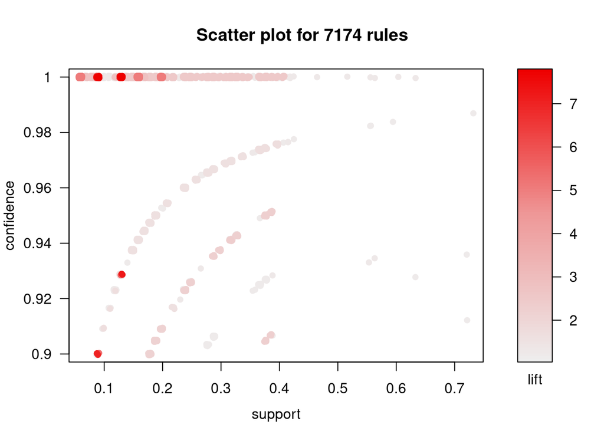

```r
plot(rules)
```

Add some jitter (randomly move points) to show how many rules have the same confidence and support value.

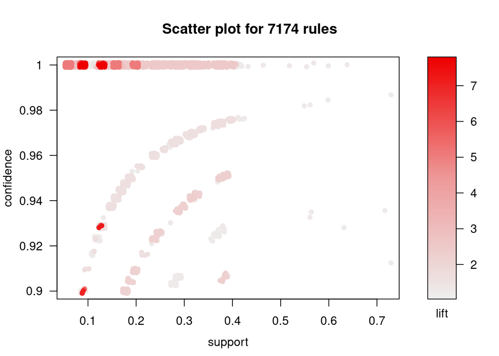

```r
plot(rules, control=list(jitter = .5))
```

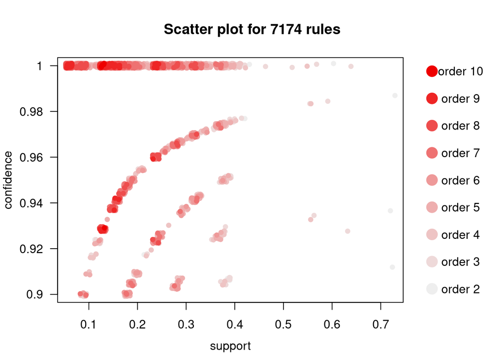

```r
plot(rules, shading = "order", control = list(jitter = .5))
```

```r
#plot(rules, interactive = TRUE)
```

Grouped plot

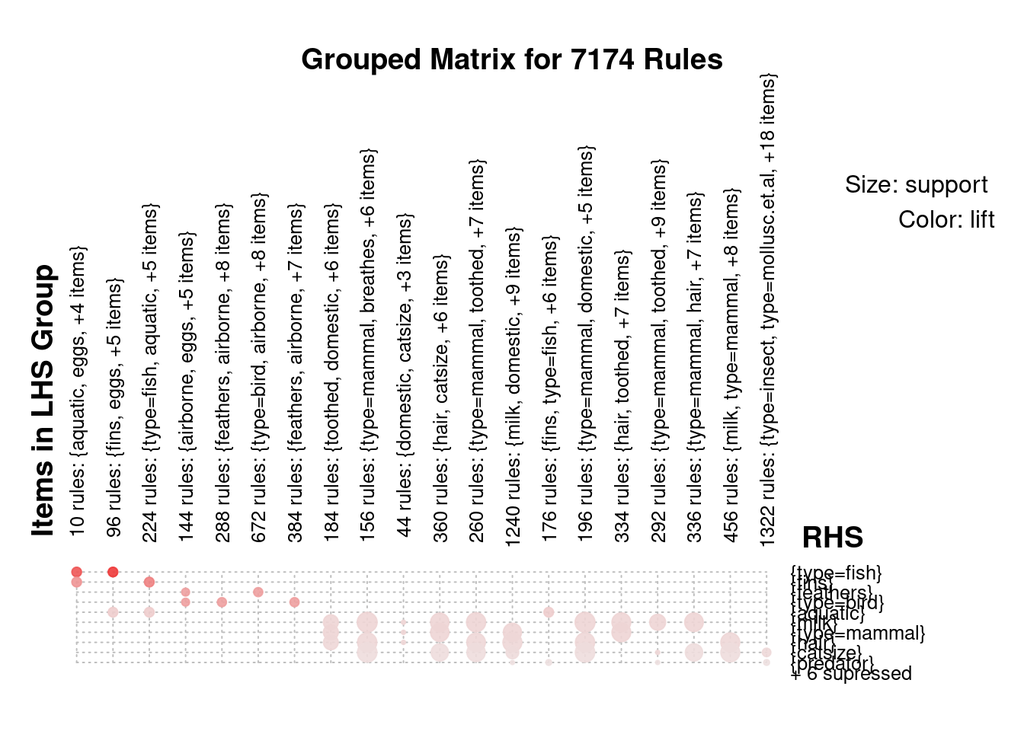

```r
plot(rules, method = "grouped")
```

```r
#plot(rules, method = "grouped", engine = "interactive")
```

As a graph

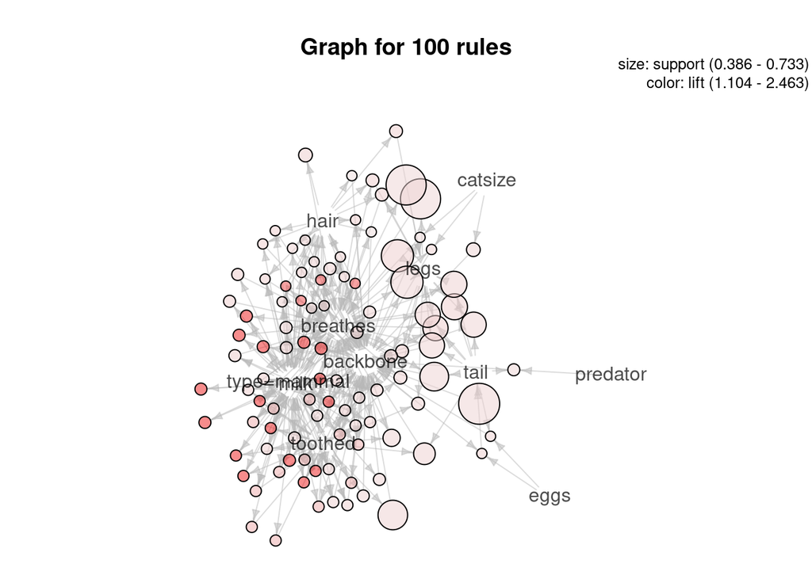

```r
plot(rules, method = "graph")
```

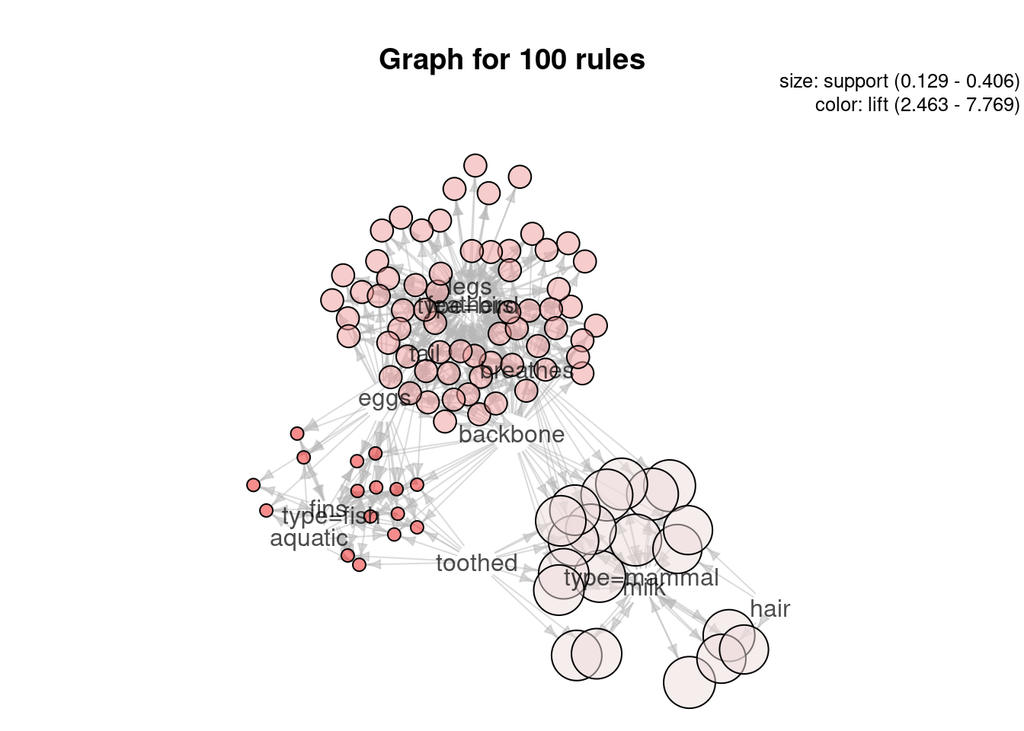

```r
plot(head(rules, by = "phi", n = 100), method = "graph")
```

## More interactive visualization

Interactive visualizations using datatable and plotly can be found here. **Note:** the page might load slowly because it makes heavy use of client side computation.